# Codebook

**Authors:** Lauren Baker  
Documenting existing data files of DaanMatch with information about location, owner, "version", source etc.

```python
import boto3
import numpy as np
import pandas as pd
pd.plotting.register_matplotlib_converters()
import matplotlib.pyplot as plt
%matplotlib inline
from collections import Counter
import statistics
```

```python
client = boto3.client('s3')
resource = boto3.resource('s3')
my_bucket = resource.Bucket('daanmatchdatafiles')
```

# Goa proforma_panchayat.xlsx

## TOC:

- About this dataset
- Cleaned datasets
- What's in this dataset
- Codebook
  - Missing values
  - Summary statistics
- Columns
  - Sheet A
    - Sr.No
    - Name of the District along with State
    - Name of Village Panchayat
    - Name of Sarpanch
    - Address with Pin Code
    - Mobile No./Email Address
  - Sheet B
    - Sr.No
    - Name of the District along with State
    - Name of Gram Panchayat
    - Gram Panchayat Bhawan Adress with Pin Code
  - Sheet C
    - Sr.No
    - Name of the District along with State
    - Name of Panchayat Officer (V.P. Secretary)
    - Mobile No.
    - Email Address
  - Sheet E
    - Sr.No
    - Name of District along with State
    - Name of Disctrict Panchayat President
    - Address with Pin Code
    - Mobile No. / Email Address
  - Sheet F
    - Sr.No
    - Name of the State
    - Name of the Nodal Officer / Designation
    - Mobile No. / Email Address
    - Postal Details

**About this dataset**  
Data provided by: Unknown.  
Source: https://daanmatchdatafiles.s3.us-west-1.amazonaws.com/Goa+proforma_panchayat.xlsx  
Type: xlsx  
Last Modified: June 14, 2021, 21:47:22 (UTC-07:00)  
Size: 50.8 KB

```python
path = "s3://daanmatchdatafiles/Goa proforma_panchayat.xlsx"
goa_proforma = pd.ExcelFile(path)
print(goa_proforma.sheet_names)
```

```
['(A)', '(B)', '(C)', '(D)', '(E)', '(F)']
```

```python
goa_proforma_A = goa_proforma.parse('(A)')
goa_proforma_A.head()
```

|  | Unnamed: 0 | Unnamed: 1 | Unnamed: 2 | Unnamed: 3 | Unnamed: 4 | Unnamed: 5 |
| --- | --- | --- | --- | --- | --- | --- |
| 0 | Sr.No | Name of the District along with State | Name of Village Panchayat | Name of Sarpanch | Address with Pin Code | Mobile No./Email Address |
| 1 | NaN | North Goa, V.P. Dhargalim | Dhargalim | Shri. Murarri Waradkar (Administrator) | Mahakhajan, Dhargal, Pernem -Goa 403512 | 9823717910 |
| 2 | NaN | North Goa, V.P. Arambol | Arambol | Smt. Pranali P. Vaigankar | H. No. 302/1, Khalchawada, Arambol, Pernem – G... | 8007881645 |
| 3 | NaN | North Goa, V.P. Khajne-Amere-Poroscodem | Khajne-Amere-Porascadem | Smt. Jayshri Jairam Pirankar | H.No.75, Naibag, Pernem, Goa 403512 | 8390895492 |
| 4 | NaN | North Goa, V.P. Parcem | Parcem | Shri. Rama Naik | Chonsai, Parcem Pernem-Goa 403512 | 9823321192 |

```python
goa_proforma_B = goa_proforma.parse('(B)')
goa_proforma_B.head()
```

|  | PROFORMA | Unnamed: 1 | Unnamed: 2 | Unnamed: 3 |
| --- | --- | --- | --- | --- |
| 0 | NaN | NaN | NaN | NaN |
| 1 | (B) | NaN | NaN | NaN |
| 2 | NaN | NaN | NaN | NaN |
| 3 | Sr.No | Name of the District along with State | Name of Gram Panchayat | Gram Panchayat Bhawan Adress with Pin Code |
| 4 | 1 | North Goa, Goa | Dhargalim | Dhargalim, Pernem - Goa 403513 |

```python
goa_proforma_C = goa_proforma.parse('(C)')
goa_proforma_C.head()
```

|  | PROFORMA | Unnamed: 1 | Unnamed: 2 | Unnamed: 3 | Unnamed: 4 |
| --- | --- | --- | --- | --- | --- |
| 0 | NaN | NaN | NaN | NaN | NaN |
| 1 | (C) | NaN | NaN | NaN | NaN |
| 2 | NaN | NaN | NaN | NaN | NaN |
| 3 | Sr.No | Name of the District along with State | Name of Panchayat Officer (V.P. Secretary) | Mobile No. | Email Address |
| 4 | 1 | North Goa, Goa | Shri. Subodh Prabhu | 9970451419 | NaN |

```python
goa_proforma_D = goa_proforma.parse('(D)')
goa_proforma_D.head()
```

|  | PROFORMA | Unnamed: 1 | Unnamed: 2 | Unnamed: 3 | Unnamed: 4 |
| --- | --- | --- | --- | --- | --- |
| 0 | NaN | NaN | NaN | NaN | NaN |
| 1 | (D) | NaN | NaN | NaN | NaN |
| 2 | NaN | NaN | NaN | NaN | NaN |
| 3 | Sr.No | Name of the District along with State | Name of Block Panchayat President | Address with Pin Code | Mobile No. / Email Address |
| 4 | 1 | GOA | NaN | NaN | NaN |

```python
goa_proforma_E = goa_proforma.parse('(E)')
goa_proforma_E.head()
```

|  | (E) | Unnamed: 1 | Unnamed: 2 | Unnamed: 3 | Unnamed: 4 |
| --- | --- | --- | --- | --- | --- |
| 0 | NaN | NaN | NaN | NaN | NaN |
| 1 | Sr.No | Name of District along with State | Name of Disctrict Panchayat President | Address with Pin Code | Mobile No. / Email Address |
| 2 | 1 | North Goa, GOA | Smt.Ankita L Navelkar - Adhyaksha | H.No 247, Lalbag, Vithalpur, P.O. Sanquelim, B... | 9923446211 |
| 3 | 2 | North Goa, GOA | Shri. Vasudev L Korgaonkar - Upadhyaksha | H.No 353, Khalap wado, Canca, Bardez - Goa | 9850453006 |
| 4 | 3 | South Goa, GOA | Shri. Navnaath G. Naik - Adhyaksha | H.No 164/1, Bhaati, Sanguem-Goa | 9421240037 |

```python
goa_proforma_F = goa_proforma.parse('(F)')
goa_proforma_F.head()
```

|  | PROFORMA | Unnamed: 1 | Unnamed: 2 | Unnamed: 3 | Unnamed: 4 |
| --- | --- | --- | --- | --- | --- |
| 0 | NaN | NaN | NaN | NaN | NaN |
| 1 | (F) | NaN | NaN | NaN | NaN |
| 2 | NaN | NaN | NaN | NaN | NaN |
| 3 | Sr.No | Name of the State | Name of the Nodal Officer / Designation | Mobile No. / Email Address | Postal Details |
| 4 | 1 | GOA | Shri. Gurudas Pilarnekar, Director, Directorat... | 9763554136 dir-panc.goa@nic.in | 3rd lift, 3rd floor, Junta House, Panaji - Goa |

**Cleaned datasets**

Cleaning up the data in Sheet A:

```python
goa_proforma_A.rename(columns = {'Unnamed: 0' : 'Sr.No',
                                 'Unnamed: 1' : 'Name of the District along with State',
                                 'Unnamed: 2' : 'Name of Village Panchayat',
                                 'Unnamed: 3' : 'Name of Sarpanch',
                                 'Unnamed: 4' : 'Address with Pin Code',
                                 'Unnamed: 5' : 'Mobile No./Email Address'}, inplace = True)
goa_proforma_A = goa_proforma_A.iloc[1:, :]
goa_proforma_A = goa_proforma_A.reset_index(drop = True)
goa_proforma_A
```

|  | Sr.No | Name of the District along with State | Name of Village Panchayat | Name of Sarpanch | Address with Pin Code | Mobile No./Email Address |
| --- | --- | --- | --- | --- | --- | --- |
| 0 | NaN | North Goa, V.P. Dhargalim | Dhargalim | Shri. Murarri Waradkar (Administrator) | Mahakhajan, Dhargal, Pernem -Goa 403512 | 9823717910 |
| 1 | NaN | North Goa, V.P. Arambol | Arambol | Smt. Pranali P. Vaigankar | H. No. 302/1, Khalchawada, Arambol, Pernem – G... | 8007881645 |
| 2 | NaN | North Goa, V.P. Khajne-Amere-Poroscodem | Khajne-Amere-Porascadem | Smt. Jayshri Jairam Pirankar | H.No.75, Naibag, Pernem, Goa 403512 | 8390895492 |
| 3 | NaN | North Goa, V.P. Parcem | Parcem | Shri. Rama Naik | Chonsai, Parcem Pernem-Goa 403512 | 9823321192 |
| 4 | NaN | North Goa, V.P. Ibrampur - Hankahne | Ibrampur-Hankahne | Shri. Ashok Mahadev Dhauskar | H.No. 89, Ibrampur-Pernem – Goa 403512 | 9421240482 |
| ... | ... | ... | ... | ... | ... | ... |
| 182 | NaN | South Goa | Majorda Utorda Calata | Mr.Moises A. Vaz | --- | 9922929636 |
| 183 | NaN | South Goa | Chicalim | Mrs.Prajoti L. Kudaikar | --- | 9049843109 |
| 184 | NaN | South Goa | Cansaulim-Arossim-Cuelim | Mrs.FilomenaD,Mello | --- | 9545485086 |
| 185 | NaN | South Goa | Velsao-Pale-Issorcim | Mr. Henrique D’Mello | --- | 9657896983 |
| 186 | NaN | South Goa | Sancoale | Mr.Ramakant Narayan Borkar | --- | 9860187445 |

187 rows × 6 columns

Cleaning up the data in Sheet B:

```python
goa_proforma_B.rename(columns = {'PROFORMA' : 'Sr.No',
                                 'Unnamed: 1' : 'Name of the District along with State',
                                 'Unnamed: 2' : 'Name of Gram Panchayat',
                                 'Unnamed: 3' : 'Gram Panchayat Bhawan Adress with Pin Code'}, inplace = True)
goa_proforma_B = goa_proforma_B.iloc[4:, :]
goa_proforma_B = goa_proforma_B.reset_index(drop = True)
goa_proforma_B
```

|  | Sr.No | Name of the District along with State | Name of Gram Panchayat | Gram Panchayat Bhawan Adress with Pin Code |
| --- | --- | --- | --- | --- |
| 0 | 1 | North Goa, Goa | Dhargalim | Dhargalim, Pernem - Goa 403513 |
| 1 | 2 | North Goa, Goa | Arambol | Arambol, Pernem - Goa 403524 |
| 2 | 3 | North Goa, Goa | Khajne-Amere-Porascadem | Khajne-Amere-Porascadem, Pernem - Goa 403512 |
| 3 | 4 | North Goa, Goa | Parcem | Parcem, Pernem - Goa 403512 |
| 4 | 5 | North Goa, Goa | Ibrampur-Hankahne | Ibrampur-Hankahne, Pernem - Goa 403503 |
| ... | ... | ... | ... | ... |
| 182 | 183 | South Goa, Goa | Majorda Utorda Calata | Majorda Utorda Calata, Mormugoa - Goa |
| 183 | 184 | South Goa, Goa | Chicalim | Chicalim, Mormugoa - Goa |
| 184 | 185 | South Goa, Goa | Cansaulim-Arossim-Cuelim | Cansaulim-Arossim-Cuelim, Mormugoa - Goa |
| 185 | 186 | South Goa, Goa | Velsao-Pale-Issorcim | Velsao-Pale-Issorcim, Mormugoa - Goa |
| 186 | 187 | South Goa, Goa | Sancoale | Sancoale,Mormugoa - Goa |

187 rows × 4 columns

Cleaning up the data in Sheet C:

```python
goa_proforma_C.rename(columns = {'PROFORMA' : 'Sr.No',
                                 'Unnamed: 1' : 'Name of the District along with State',
                                 'Unnamed: 2' : 'Name of Panchayat Officer (V.P. Secretary)',
                                 'Unnamed: 3' : 'Mobile No.',
                                 'Unnamed: 4' : 'Email Address'}, inplace = True)
goa_proforma_C = goa_proforma_C.iloc[4:, :]
goa_proforma_C = goa_proforma_C.reset_index(drop = True)
goa_proforma_C
```

|  | Sr.No | Name of the District along with State | Name of Panchayat Officer (V.P. Secretary) | Mobile No. | Email Address |
| --- | --- | --- | --- | --- | --- |
| 0 | 1 | North Goa, Goa | Shri. Subodh Prabhu | 9970451419 | NaN |
| 1 | 2 | North Goa, Goa | Shri. Dharmendra Govekar | 9764364603 | NaN |
| 2 | 3 | North Goa, Goa | Shri. Rui Cardozo | 9822282013 | NaN |
| 3 | 4 | North Goa, Goa | Shri. Rajesh Assolkar | 9764007587 | NaN |
| 4 | 5 | North Goa, Goa | Shri. Amit Prabhu | 9764512999 | NaN |
| ... | ... | ... | ... | ... | ... |
| 180 | 181 | South Goa, Goa | Shri Babuso M Tilve | 9420107912 | NaN |
| 181 | 182 | South Goa, Goa | Smt. Gauri M. Velip | 9421255686 | NaN |
| 182 | 183 | South Goa, Goa | Shri. Dinkar V. Kossambe | 9423503452 | NaN |
| 183 | 184 | South Goa, Goa | Shri Gurudas Gaonkar | 8554904684 | NaN |
| 184 | 185 | South Goa, Goa | Shri. John Colaco | 9921170574 | NaN |

185 rows × 5 columns

Cleaning up the data in Sheet D:

```python
goa_proforma_D
```

|  | PROFORMA | Unnamed: 1 | Unnamed: 2 | Unnamed: 3 | Unnamed: 4 |
| --- | --- | --- | --- | --- | --- |
| 0 | NaN | NaN | NaN | NaN | NaN |
| 1 | (D) | NaN | NaN | NaN | NaN |
| 2 | NaN | NaN | NaN | NaN | NaN |
| 3 | Sr.No | Name of the District along with State | Name of Block Panchayat President | Address with Pin Code | Mobile No. / Email Address |
| 4 | 1 | GOA | NaN | NaN | NaN |

Sheet D contains no information, so we can ignore it and proceed with cleaning the other sheets.

Cleaning up the data in Sheet E:

```python
goa_proforma_E.rename(columns = {'(E)' : 'Sr.No',
                                 'Unnamed: 1' : 'Name of District along with State',
                                 'Unnamed: 2' : 'Name of District Panchayat President',
                                 'Unnamed: 3' : 'Address with Pin Code',
                                 'Unnamed: 4' : 'Mobile No. / Email Address'}, inplace = True)
goa_proforma_E = goa_proforma_E.iloc[2:, :]
goa_proforma_E = goa_proforma_E.reset_index(drop = True)
goa_proforma_E
```

|  | Sr.No | Name of District along with State | Name of District Panchayat President | Address with Pin Code | Mobile No. / Email Address |
| --- | --- | --- | --- | --- | --- |
| 0 | 1 | North Goa, GOA | Smt.Ankita L Navelkar - Adhyaksha | H.No 247, Lalbag, Vithalpur, P.O. Sanquelim, B... | 9923446211 |
| 1 | 2 | North Goa, GOA | Shri. Vasudev L Korgaonkar - Upadhyaksha | H.No 353, Khalap wado, Canca, Bardez - Goa | 9850453006 |
| 2 | 3 | South Goa, GOA | Shri. Navnaath G. Naik - Adhyaksha | H.No 164/1, Bhaati, Sanguem-Goa | 9421240037 |
| 3 | 4 | South Goa, GOA | Smt. Chitra Parab Fadte - Upadhyaksha | H.No 73, Near Mal, Kharwada, Bandora, Ponda - Goa | 9049666058 |

Cleaning up the data in Sheet F:

```python
goa_proforma_F
```

|  | PROFORMA | Unnamed: 1 | Unnamed: 2 | Unnamed: 3 | Unnamed: 4 |
| --- | --- | --- | --- | --- | --- |
| 0 | NaN | NaN | NaN | NaN | NaN |
| 1 | (F) | NaN | NaN | NaN | NaN |
| 2 | NaN | NaN | NaN | NaN | NaN |
| 3 | Sr.No | Name of the State | Name of the Nodal Officer / Designation | Mobile No. / Email Address | Postal Details |
| 4 | 1 | GOA | Shri. Gurudas Pilarnekar, Director, Directorat... | 9763554136 dir-panc.goa@nic.in | 3rd lift, 3rd floor, Junta House, Panaji - Goa |

```python
goa_proforma_F.rename(columns = {'PROFORMA' : 'Sr.No',
                                 'Unnamed: 1' : 'Name of the State',
                                 'Unnamed: 2' : 'Name of the Nodal Officer / Designation',
                                 'Unnamed: 3' : 'Mobile No. / Email Address',
                                 'Unnamed: 4' : 'Postal Details'}, inplace = True)
goa_proforma_F = goa_proforma_F.iloc[4:, :]
goa_proforma_F = goa_proforma_F.reset_index(drop = True)
goa_proforma_F
```

|  | Sr.No | Name of the State | Name of the Nodal Officer / Designation | Mobile No. / Email Address | Postal Details |
| --- | --- | --- | --- | --- | --- |
| 0 | 1 | GOA | Shri. Gurudas Pilarnekar, Director, Directorat... | 9763554136 dir-panc.goa@nic.in | 3rd lift, 3rd floor, Junta House, Panaji - Goa |

**What's in this dataset?**

```python
print("Sheet A:")
print("Shape:", goa_proforma_A.shape)
print("Rows:", goa_proforma_A.shape[0])
print("Columns:", goa_proforma_A.shape[1])
print("Each row is a Sarpanch in Goa.")

print('\n')
print("Sheet B:")
print("Shape:", goa_proforma_B.shape)
print("Rows:", goa_proforma_B.shape[0])
print("Columns:", goa_proforma_B.shape[1])
print("Each row is a Gram Panchayat in Goa.")

print('\n')
print("Sheet C:")
print("Shape:", goa_proforma_C.shape)
print("Rows:", goa_proforma_C.shape[0])
print("Columns:", goa_proforma_C.shape[1])
print("Each row is a Panchayat Officer in Goa.")

print('\n')
print("Sheet E:")
print("Shape:", goa_proforma_E.shape)
print("Rows:", goa_proforma_E.shape[0])
print("Columns:", goa_proforma_E.shape[1])
print("Each row is a Disctrict Panchayat President in Goa.")

print('\n')
print("Sheet F:")
print("Shape:", goa_proforma_F.shape)
print("Rows:", goa_proforma_F.shape[0])
print("Columns:", goa_proforma_F.shape[1])
print("Each row is a Nodal Officer in Goa.")
```

```
Sheet A:
Shape: (187, 6)
Rows: 187
Columns: 6
Each row is a Sarpanch in Goa.


Sheet B:
Shape: (187, 4)
Rows: 187
Columns: 4
Each row is a Gram Panchayat in Goa.


Sheet C:
Shape: (185, 5)
Rows: 185
Columns: 5
Each row is a Panchayat Officer in Goa.


Sheet E:
Shape: (4, 5)
Rows: 4
Columns: 5
Each row is a Disctrict Panchayat President in Goa.


Sheet F:
Shape: (1, 5)
Rows: 1
Columns: 5
Each row is a Nodal Officer in Goa.
```

**Codebook**

```python
print("Codebook for Sheet A:")
goa_proforma_A_columns = [column for column in goa_proforma_A.columns]
goa_proforma_A_description = ["Meant for counting, is a null column.",
                              "Name of district in Goa.",
                              "Name of the village panchayat the Sarpanch is elected in.",
                              "Name of the Sarpanch (elected offical).",
                              "The address and pin code of the Sarpanch.",
                              "The mobile phone number or email address of the Sarpanch."]
goa_proforma_A_dtypes = [dtype for dtype in goa_proforma_A.dtypes]

data_A = {"Column Name": goa_proforma_A_columns, "Description": goa_proforma_A_description, "Type": goa_proforma_A_dtypes}
goa_proforma_A_codebook = pd.DataFrame(data_A)
goa_proforma_A_codebook.style.set_properties(subset=['Description'], **{'width': '600px'})
```

```
Codebook for Sheet A:
```

|  | Column Name | Description | Type |
| --- | --- | --- | --- |
| 0 | Sr.No | Meant for counting, is a null column. | object |
| 1 | Name of the District along with State | Name of district in Goa. | object |
| 2 | Name of Village Panchayat | Name of the village panchayat the Sarpanch is elected in. | object |
| 3 | Name of Sarpanch | Name of the Sarpanch (elected offical). | object |
| 4 | Address with Pin Code | The address and pin code of the Sarpanch. | object |
| 5 | Mobile No./Email Address | The mobile phone number or email address of the Sarpanch. | object |

```python
print("Codebook for Sheet B:")
goa_proforma_B_columns = [column for column in goa_proforma_B.columns]
goa_proforma_B_description = ["Counts the number of Gram Panchayats.",
                              "Name of district in Goa.",
                              "Name of the Gram Panchayat (elected offical).",
                              "The address and pin code of the Gram Panchayat."]
goa_proforma_B_dtypes = [dtype for dtype in goa_proforma_B.dtypes]

data_B = {"Column Name": goa_proforma_B_columns, "Description": goa_proforma_B_description, "Type": goa_proforma_B_dtypes}
goa_proforma_B_codebook = pd.DataFrame(data_B)
goa_proforma_B_codebook.style.set_properties(subset=['Description'], **{'width': '600px'})
```

```
Codebook for Sheet B:
```

|  | Column Name | Description | Type |
| --- | --- | --- | --- |
| 0 | Sr.No | Counts the number of Gram Panchayats. | object |
| 1 | Name of the District along with State | Name of district in Goa. | object |
| 2 | Name of Gram Panchayat | Name of the Gram Panchayat (elected offical). | object |
| 3 | Gram Panchayat Bhawan Adress with Pin Code | The address and pin code of the Gram Panchayat. | object |

```python
print("Codebook for Sheet C:")
goa_proforma_C_columns = [column for column in goa_proforma_C.columns]
goa_proforma_C_description = ["Counts the number of Panchayat Officers.",
                              "Name of district in Goa.",
                              "Name of the Panchayat Officer (V.P. Secretary).",
                              "The mobile phone number of the Panchayat Officer.",
                              "The email address of the Panchayat Officer."]
goa_proforma_C_dtypes = [dtype for dtype in goa_proforma_C.dtypes]

data_C = {"Column Name": goa_proforma_C_columns, "Description": goa_proforma_C_description, "Type": goa_proforma_C_dtypes}
goa_proforma_C_codebook = pd.DataFrame(data_C)
goa_proforma_C_codebook.style.set_properties(subset=['Description'], **{'width': '600px'})
```

```
Codebook for Sheet C:
```

|  | Column Name | Description | Type |
| --- | --- | --- | --- |
| 0 | Sr.No | Counts the number of Panchayat Officers. | object |
| 1 | Name of the District along with State | Name of district in Goa. | object |
| 2 | Name of Panchayat Officer (V.P. Secretary) | Name of the Panchayat Officer (V.P. Secretary). | object |
| 3 | Mobile No. | The mobile phone number of the Panchayat Officer. | object |
| 4 | Email Address | The email address of the Panchayat Officer. | object |

```python
print("Codebook for Sheet E:")
goa_proforma_E_columns = [column for column in goa_proforma_E.columns]
goa_proforma_E_description = ["Counts the number of Disctrict Panchayat Presidents.",
                              "Name of district in Goa.",
                              "Name of the Disctrict Panchayat President.",
                              "The address and pin code of the Disctrict Panchayat President.",
                              "The mobile phone number or email address of the Disctrict Panchayat President."]
goa_proforma_E_dtypes = [dtype for dtype in goa_proforma_E.dtypes]

data_E = {"Column Name": goa_proforma_E_columns, "Description": goa_proforma_E_description, "Type": goa_proforma_E_dtypes}
goa_proforma_E_codebook = pd.DataFrame(data_E)
goa_proforma_E_codebook.style.set_properties(subset=['Description'], **{'width': '600px'})
```

```
Codebook for Sheet E:
```

|  | Column Name | Description | Type |
| --- | --- | --- | --- |
| 0 | Sr.No | Counts the number of Disctrict Panchayat Presidents. | object |
| 1 | Name of District along with State | Name of district in Goa. | object |
| 2 | Name of District Panchayat President | Name of the Disctrict Panchayat President. | object |
| 3 | Address with Pin Code | The address and pin code of the Disctrict Panchayat President. | object |
| 4 | Mobile No. / Email Address | The mobile phone number or email address of the Disctrict Panchayat President. | object |

```python
print("Codebook for Sheet F:")
goa_proforma_F_columns = [column for column in goa_proforma_F.columns]
goa_proforma_F_description = ["Counts the number of Nodal Officers.",
                              "Name of State in India.",
                              "Name of the Nodal Officer and their designation.",
                              "The mobile phone number or email address of the Nodal Officer.",
                              "The address and pin code of the Nodal Officer."]
goa_proforma_F_dtypes = [dtype for dtype in goa_proforma_F.dtypes]

data_F = {"Column Name": goa_proforma_F_columns, "Description": goa_proforma_F_description, "Type": goa_proforma_F_dtypes}
goa_proforma_F_codebook = pd.DataFrame(data_F)
goa_proforma_F_codebook.style.set_properties(subset=['Description'], **{'width': '600px'})
```

```
Codebook for Sheet F:
```

|  | Column Name | Description | Type |
| --- | --- | --- | --- |
| 0 | Sr.No | Counts the number of Nodal Officers. | object |
| 1 | Name of the State | Name of State in India. | object |
| 2 | Name of the Nodal Officer / Designation | Name of the Nodal Officer and their designation. | object |
| 3 | Mobile No. / Email Address | The mobile phone number or email address of the Nodal Officer. | object |
| 4 | Postal Details | The address and pin code of the Nodal Officer. | object |

**Missing values**

```python
goa_proforma_A.isnull().sum()
```

```
Sr.No                                    187
Name of the District along with State      0
Name of Village Panchayat                  0
Name of Sarpanch                           0
Address with Pin Code                     19
Mobile No./Email Address                   1
dtype: int64
```

```python
goa_proforma_B.isnull().sum()
```

```
Sr.No                                         0
Name of the District along with State         0
Name of Gram Panchayat                        0
Gram Panchayat Bhawan Adress with Pin Code    0
dtype: int64
```

```python
goa_proforma_C.isnull().sum()
```

```
Sr.No                                           0
Name of the District along with State           0
Name of Panchayat Officer (V.P. Secretary)      0
Mobile No.                                      0
Email Address                                 182
dtype: int64
```

```python
goa_proforma_E.isnull().sum()
```

```
Sr.No                                   0
Name of District along with State       0
Name of District Panchayat President    0
Address with Pin Code                   0
Mobile No. / Email Address              0
dtype: int64
```

```python
goa_proforma_F.isnull().sum()
```

```
Sr.No                                      0
Name of the State                          0
Name of the Nodal Officer / Designation    0
Mobile No. / Email Address                 0
Postal Details                             0
dtype: int64
```

**Summary statistics**

```python
goa_proforma_A.describe()
```

|  | Sr.No | Name of the District along with State | Name of Village Panchayat | Name of Sarpanch | Address with Pin Code | Mobile No./Email Address |
| --- | --- | --- | --- | --- | --- | --- |
| count | 0 | 187 | 187 | 187 | 168 | 186 |
| unique | 0 | 130 | 185 | 187 | 149 | 186 |
| top | NaN | South Goa | Querim | Shri. Sandeep D. Salgaonkar | --- | 9423224690 |
| freq | NaN | 58 | 2 | 1 | 20 | 1 |

```python
goa_proforma_B.describe()
```

|  | Sr.No | Name of the District along with State | Name of Gram Panchayat | Gram Panchayat Bhawan Adress with Pin Code |
| --- | --- | --- | --- | --- |
| count | 187 | 187 | 187 | 187 |
| unique | 187 | 2 | 185 | 187 |
| top | 1 | North Goa, Goa | Querim | Morpila, Quepem - Goa |
| freq | 1 | 102 | 2 | 1 |

```python
goa_proforma_C.describe()
```

|  | Sr.No | Name of the District along with State | Name of Panchayat Officer (V.P. Secretary) | Mobile No. | Email Address |
| --- | --- | --- | --- | --- | --- |
| count | 185 | 185 | 185 | 185 | 3 |
| unique | 185 | 2 | 175 | 171 | 3 |
| top | 1 | North Goa, Goa | Sameer Parab | --- | mailoswynmas@gmail.com |
| freq | 1 | 103 | 2 | 3 | 1 |

```python
goa_proforma_E.describe()
```

|  | Sr.No | Name of District along with State | Name of District Panchayat President | Address with Pin Code | Mobile No. / Email Address |
| --- | --- | --- | --- | --- | --- |
| count | 4 | 4 | 4 | 4 | 4 |
| unique | 4 | 2 | 4 | 4 | 4 |
| top | 1 | North Goa, GOA | Smt.Ankita L Navelkar - Adhyaksha | H.No 247, Lalbag, Vithalpur, P.O. Sanquelim, B... | 9049666058 |
| freq | 1 | 2 | 1 | 1 | 1 |

```python
goa_proforma_F.describe()
```

|  | Sr.No | Name of the State | Name of the Nodal Officer / Designation | Mobile No. / Email Address | Postal Details |
| --- | --- | --- | --- | --- | --- |
| count | 1 | 1 | 1 | 1 | 1 |
| unique | 1 | 1 | 1 | 1 | 1 |
| top | 1 | GOA | Shri. Gurudas Pilarnekar, Director, Directorat... | 9763554136 dir-panc.goa@nic.in | 3rd lift, 3rd floor, Junta House, Panaji - Goa |
| freq | 1 | 1 | 1 | 1 | 1 |

## Columns

### Sheet A

Sheet A contains information about Sarpanchs in Goa.

### Sr.No.

Meant for counting, is a null column.

```python
column = goa_proforma_A["Sr.No"]
column
```

```
0      NaN
1      NaN
2      NaN
3      NaN
4      NaN
      ...
182    NaN
183    NaN
184    NaN
185    NaN
186    NaN
Name: Sr.No, Length: 187, dtype: object
```

```python
print("No. of unique values:", len(column.unique()))
counter = dict(Counter(column))
duplicates = {key:value for key, value in counter.items() if value > 1}
print("Duplicates:", duplicates)
if len(duplicates) > 0:
    print("No. of duplicates:", len(duplicates))

print("No. of null values:", sum(column.isnull()))
```

```
No. of unique values: 1
Duplicates: {nan: 187}
No. of duplicates: 1
No. of null values: 187
```

### Name of the District along with State

Name of district in Goa.

```python
column = goa_proforma_A["Name of the District along with State"]
column
```

```
0                    North Goa, V.P. Dhargalim
1                      North Goa, V.P. Arambol
2      North Goa, V.P. Khajne-Amere-Poroscodem
3                       North Goa, V.P. Parcem
4          North Goa, V.P. Ibrampur - Hankahne
                        ...
182                                  South Goa
183                                  South Goa
184                                  South Goa
185                                  South Goa
186                                  South Goa
Name: Name of the District along with State, Length: 187, dtype: object
```

```python
print("No. of unique values:", len(column.unique()))
counter = dict(Counter(column))
duplicates = {key:value for key, value in counter.items() if value > 1}
print("Duplicates:", duplicates)
if len(duplicates) > 0:
    print("No. of duplicates:", len(duplicates))

print("No. of null values:", sum(column.isnull()))
```

```
No. of unique values: 130
Duplicates: {'South Goa': 58}
No. of duplicates: 1
No. of null values: 0
```

```python
districts = column.apply(lambda x: str(x[:9]))
districts
```

```
0      North Goa
1      North Goa
2      North Goa
3      North Goa
4      North Goa
         ...
182    South Goa
183    South Goa
184    South Goa
185    South Goa
186    South Goa
Name: Name of the District along with State, Length: 187, dtype: object
```

```python
print("Unique values:", districts.unique())
print("No. of unique values:", len(districts.unique()))

# Table of number of Sarpanchs in each district
table = districts.value_counts().rename_axis('District').reset_index(name='Count')
table
```

```
Unique values: ['North Goa' 'South Goa']
No. of unique values: 2
```

|  | District | Count |
| --- | --- | --- |
| 0 | North Goa | 102 |
| 1 | South Goa | 85 |

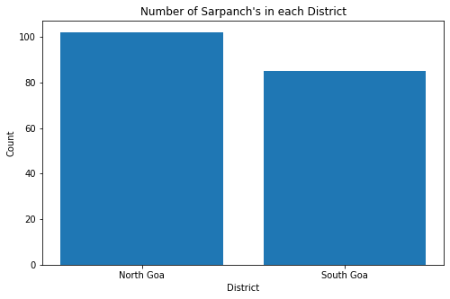

```python
plt.figure(figsize = (8, 5))
plt.bar(table["District"], table["Count"])
plt.title("Number of Sarpanch's in each District")
plt.xlabel("District")
plt.ylabel("Count")
plt.show()
```

### Name of Village Panchayat

Name of the village panchayat the Sarpanch is elected in.

```python
column = goa_proforma_A["Name of Village Panchayat"]
column
```

```
0                     Dhargalim
1                       Arambol
2       Khajne-Amere-Porascadem
3                        Parcem
4             Ibrampur-Hankahne
                 ...
182       Majorda Utorda Calata
183                    Chicalim
184    Cansaulim-Arossim-Cuelim
185        Velsao-Pale-Issorcim
186                    Sancoale
Name: Name of Village Panchayat, Length: 187, dtype: object
```

```python
print("No. of unique values:", len(column.unique()))
counter = dict(Counter(column))
duplicates = {key:value for key, value in counter.items() if value > 1}
print("Duplicates:", duplicates)
if len(duplicates) > 0:
    print("No. of duplicates:", len(duplicates))

print("No. of null values:", sum(column.isnull()))
```

```
No. of unique values: 185
Duplicates: {'Querim': 2, 'Navelim': 2}
No. of duplicates: 2
No. of null values: 0
```

### Name of Sarpanch

Name of the Sarpanch (elected offical).

```python
column = goa_proforma_A["Name of Sarpanch"]
column
```

```
0      Shri.  Murarri Waradkar (Administrator)
1                    Smt. Pranali P. Vaigankar
2                 Smt. Jayshri Jairam Pirankar
3                              Shri. Rama Naik
4                 Shri. Ashok Mahadev Dhauskar
                        ...
182                           Mr.Moises A. Vaz
183                    Mrs.Prajoti L. Kudaikar
184                        Mrs.FilomenaD,Mello
185                       Mr. Henrique D’Mello
186                 Mr.Ramakant Narayan Borkar
Name: Name of Sarpanch, Length: 187, dtype: object
```

```python
print("No. of unique values:", len(column.unique()))
counter = dict(Counter(column))
duplicates = {key:value for key, value in counter.items() if value > 1}
print("Duplicates:", duplicates)
if len(duplicates) > 0:
    print("No. of duplicates:", len(duplicates))

print("No. of null values:", sum(column.isnull()))
```

```
No. of unique values: 187
Duplicates: {}
No. of null values: 0
```

```python
#Titles of officers
titles = column.apply(lambda x: str(x[:3]))
smt = 0; shr = 0; mr = 0; mrs = 0; none = 0
for title in titles:
    if (title == 'Smt'):
        smt += 1
    elif (title == 'Shr'):
        shr += 1
    elif (title == 'Mrs'):
        mrs += 1
    elif (title == 'Mr.'):
        mr += 1
    else:
        none += 1
titles_df = pd.DataFrame(data = {'Titles' : ['Smt.', 'Shri.', 'Mr.', 'Mrs.', 'None'],
                                 'Counts' : [smt, shr, mr, mrs, none]})
titles_df
```

|  | Titles | Counts |
| --- | --- | --- |
| 0 | Smt. | 34 |
| 1 | Shri. | 48 |
| 2 | Mr. | 8 |
| 3 | Mrs. | 4 |
| 4 | None | 93 |

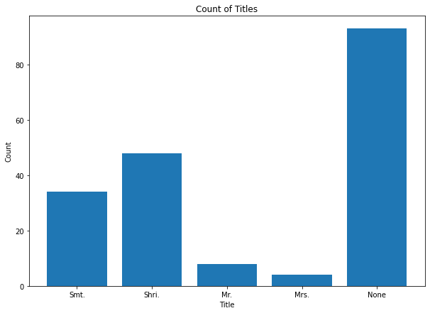

```python
# Plot number of titles'
plt.figure(figsize = (10, 7))
plt.bar(titles_df["Titles"], titles_df["Counts"])
plt.title("Count of Titles")
plt.xlabel("Title")
plt.ylabel('Count')
plt.show()
```

### Address with Pin Code

The address and pin code of the Sarpanch.

```python
column = goa_proforma_A["Address with Pin Code"]
column
```

```
0                Mahakhajan, Dhargal, Pernem -Goa 403512
1      H. No. 302/1, Khalchawada, Arambol, Pernem – G...
2                    H.No.75, Naibag, Pernem, Goa 403512
3                      Chonsai, Parcem Pernem-Goa 403512
4                 H.No. 89, Ibrampur-Pernem – Goa 403512
                             ...
182                                                  ---
183                                                  ---
184                                                  ---
185                                                  ---
186                                                  ---
Name: Address with Pin Code, Length: 187, dtype: object
```

```python
print("No. of unique values:", len(column.unique()))
counter = dict(Counter(column))
duplicates = {key:value for key, value in counter.items() if value > 1}
print("Duplicates:", duplicates)
if len(duplicates) > 0:
    print("No. of duplicates:", len(duplicates))

print("No. of null values:", sum(column.isnull()))
```

```
No. of unique values: 150
Duplicates: {nan: 19, ' ---': 20}
No. of duplicates: 2
No. of null values: 19
```

### Mobile No./Email Address

The mobile phone number or email address of the Sarpanch.

```python
column = goa_proforma_A["Mobile No./Email Address"]
column
```

```
0      9823717910
1      8007881645
2      8390895492
3      9823321192
4      9421240482
          ...
182    9922929636
183    9049843109
184    9545485086
185    9657896983
186    9860187445
Name: Mobile No./Email Address, Length: 187, dtype: object
```

```python
print("No. of unique values:", len(column.unique()))
counter = dict(Counter(column))
duplicates = {key:value for key, value in counter.items() if value > 1}
print("Duplicates:", duplicates)
if len(duplicates) > 0:
    print("No. of duplicates:", len(duplicates))

print("No. of null values:", sum(column.isnull()))
```

```
No. of unique values: 187
Duplicates: {}
No. of null values: 1
```

### Sheet B

Sheet B contains information about Gram Panchayats in Goa.

### Sr.No.

Counts the number of Gram Panchayats.

```python
column = goa_proforma_B["Sr.No"]
column
```

```
0        1
1        2
2        3
3        4
4        5
      ...
182    183
183    184
184    185
185    186
186    187
Name: Sr.No, Length: 187, dtype: object
```

```python
print("No. of unique values:", len(column.unique()))
counter = dict(Counter(column))
duplicates = {key:value for key, value in counter.items() if value > 1}
print("Duplicates:", duplicates)
if len(duplicates) > 0:
    print("No. of duplicates:", len(duplicates))

print("No. of null values:", sum(column.isnull()))
```

```
No. of unique values: 187
Duplicates: {}
No. of null values: 0
```

### Name of the District along with State

Name of district in Goa.

```python
column = goa_proforma_B["Name of the District along with State"]
column
```

```
0      North Goa, Goa
1      North Goa, Goa
2      North Goa, Goa
3      North Goa, Goa
4      North Goa, Goa
            ...
182    South Goa, Goa
183    South Goa, Goa
184    South Goa, Goa
185    South Goa, Goa
186    South Goa, Goa
Name: Name of the District along with State, Length: 187, dtype: object
```

```python
print("No. of unique values:", len(column.unique()))
counter = dict(Counter(column))
duplicates = {key:value for key, value in counter.items() if value > 1}
print("Duplicates:", duplicates)
if len(duplicates) > 0:
    print("No. of duplicates:", len(duplicates))

print("No. of null values:", sum(column.isnull()))
```

```
No. of unique values: 2
Duplicates: {'North Goa, Goa': 102, 'South Goa, Goa': 85}
No. of duplicates: 2
No. of null values: 0
```

```python
districts = column.apply(lambda x: str(x[:9]))

print("Unique values:", districts.unique())
print("No. of unique values:", len(districts.unique()))

# Table of number of Sarpanchs in each district
table = districts.value_counts().rename_axis('District').reset_index(name='Count')
table
```

```
Unique values: ['North Goa' 'South Goa']
No. of unique values: 2
```

|  | District | Count |
| --- | --- | --- |
| 0 | North Goa | 102 |
| 1 | South Goa | 85 |

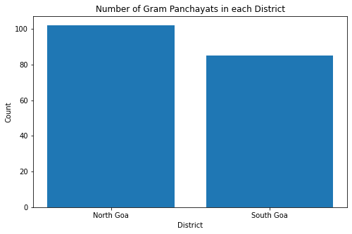

```python
plt.figure(figsize = (8, 5))
plt.bar(table["District"], table["Count"])
plt.title("Number of Gram Panchayats in each District")
plt.xlabel("District")
plt.ylabel("Count")
plt.show()
```

### Name of Gram Panchayat

Name of the Gram Panchayat (elected offical).

```python
column = goa_proforma_B["Name of Gram Panchayat"]
column
```

```
0                     Dhargalim
1                       Arambol
2       Khajne-Amere-Porascadem
3                        Parcem
4             Ibrampur-Hankahne
                 ...
182       Majorda Utorda Calata
183                    Chicalim
184    Cansaulim-Arossim-Cuelim
185        Velsao-Pale-Issorcim
186                    Sancoale
Name: Name of Gram Panchayat, Length: 187, dtype: object
```

```python
print("No. of unique values:", len(column.unique()))
counter = dict(Counter(column))
duplicates = {key:value for key, value in counter.items() if value > 1}
print("Duplicates:", duplicates)
if len(duplicates) > 0:
    print("No. of duplicates:", len(duplicates))

print("No. of null values:", sum(column.isnull()))
```

```
No. of unique values: 185
Duplicates: {'Querim': 2, 'Navelim': 2}
No. of duplicates: 2
No. of null values: 0
```

```python
goa_proforma_B[goa_proforma_B["Name of Gram Panchayat"].isin(duplicates)].sort_values('Name of Gram Panchayat')
```

|  | Sr.No | Name of the District along with State | Name of Gram Panchayat | Gram Panchayat Bhawan Adress with Pin Code |
| --- | --- | --- | --- | --- |
| 93 | 94 | North Goa, Goa | Navelim | Navelim, Bicholim - Goa |
| 129 | 130 | South Goa, Goa | Navelim | Navelim, Salcete - Goa |
| 81 | 82 | North Goa, Goa | Querim | Querim,Sattari - Goa |
| 113 | 114 | South Goa, Goa | Querim | Querim, Ponda - Goa |

### Gram Panchayat Bhawan Adress with Pin Code

The address and pin code of the Gram Panchayat.

```python
column = goa_proforma_B["Gram Panchayat Bhawan Adress with Pin Code"]
column
```

```
0                    Dhargalim, Pernem - Goa 403513
1                      Arambol, Pernem - Goa 403524
2      Khajne-Amere-Porascadem, Pernem - Goa 403512
3                       Parcem, Pernem - Goa 403512
4            Ibrampur-Hankahne, Pernem - Goa 403503
                           ...
182           Majorda Utorda Calata, Mormugoa - Goa
183                        Chicalim, Mormugoa - Goa
184        Cansaulim-Arossim-Cuelim, Mormugoa - Goa
185            Velsao-Pale-Issorcim, Mormugoa - Goa
186                         Sancoale,Mormugoa - Goa
Name: Gram Panchayat Bhawan Adress with Pin Code, Length: 187, dtype: object
```

```python
print("No. of unique values:", len(column.unique()))
counter = dict(Counter(column))
duplicates = {key:value for key, value in counter.items() if value > 1}
print("Duplicates:", duplicates)
if len(duplicates) > 0:
    print("No. of duplicates:", len(duplicates))

print("No. of null values:", sum(column.isnull()))
```

```
No. of unique values: 187
Duplicates: {}
No. of null values: 0
```

### Sheet C

Sheet C contains information about Panchayat Officers in Goa.

### Sr.No.

Counts the number of Panchayat Officers.

```python
column = goa_proforma_C["Sr.No"]
column
```

```
0        1
1        2
2        3
3        4
4        5
      ...
180    181
181    182
182    183
183    184
184    185
Name: Sr.No, Length: 185, dtype: object
```

```python
print("No. of unique values:", len(column.unique()))
counter = dict(Counter(column))
duplicates = {key:value for key, value in counter.items() if value > 1}
print("Duplicates:", duplicates)
if len(duplicates) > 0:
    print("No. of duplicates:", len(duplicates))

print("No. of null values:", sum(column.isnull()))
```

```
No. of unique values: 185
Duplicates: {}
No. of null values: 0
```

### Name of the District along with State

Name of district in Goa.

```python
column = goa_proforma_C["Name of the District along with State"]
column
```

```
0      North Goa, Goa
1      North Goa, Goa
2      North Goa, Goa
3      North Goa, Goa
4      North Goa, Goa
            ...
180    South Goa, Goa
181    South Goa, Goa
182    South Goa, Goa
183    South Goa, Goa
184    South Goa, Goa
Name: Name of the District along with State, Length: 185, dtype: object
```

```python
print("No. of unique values:", len(column.unique()))
counter = dict(Counter(column))
duplicates = {key:value for key, value in counter.items() if value > 1}
print("Duplicates:", duplicates)
if len(duplicates) > 0:
    print("No. of duplicates:", len(duplicates))

print("No. of null values:", sum(column.isnull()))
```

```
No. of unique values: 2
Duplicates: {'North Goa, Goa': 103, 'South Goa, Goa': 82}
No. of duplicates: 2
No. of null values: 0
```

```python
districts = column.apply(lambda x: str(x[:9]))

print("Unique values:", districts.unique())
print("No. of unique values:", len(districts.unique()))

# Table of number of Sarpanchs in each district
table = districts.value_counts().rename_axis('District').reset_index(name='Count')
table
```

```
Unique values: ['North Goa' 'South Goa']
No. of unique values: 2
```

|  | District | Count |
| --- | --- | --- |
| 0 | North Goa | 103 |
| 1 | South Goa | 82 |

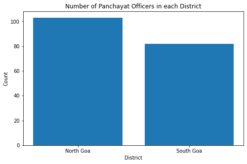

```python
plt.figure(figsize = (8, 5))
plt.bar(table["District"], table["Count"])
plt.title("Number of Panchayat Officers in each District")
plt.xlabel("District")
plt.ylabel("Count")
plt.show()
```

### Name of Panchayat Officer (V.P. Secretary)

Name of the Panchayat Officer (V.P. Secretary).

```python
column = goa_proforma_C["Name of Panchayat Officer (V.P. Secretary)"]
column
```

```
0            Shri. Subodh Prabhu
1      Shri.  Dharmendra Govekar
2              Shri. Rui Cardozo
3          Shri. Rajesh Assolkar
4              Shri. Amit Prabhu
                 ...
180          Shri Babuso M Tilve
181          Smt. Gauri M. Velip
182     Shri. Dinkar V. Kossambe
183         Shri Gurudas Gaonkar
184            Shri. John Colaco
Name: Name of Panchayat Officer (V.P. Secretary), Length: 185, dtype: object
```

```python
print("No. of unique values:", len(column.unique()))
counter = dict(Counter(column))
duplicates = {key:value for key, value in counter.items() if value > 1}
print("Duplicates:", duplicates)
if len(duplicates) > 0:
    print("No. of duplicates:", len(duplicates))

print("No. of null values:", sum(column.isnull()))
```

```
No. of unique values: 175
Duplicates: {'Shri. Francis Fernandes': 2, 'Shri. Clifton Azavedo': 2, 'Shri. Vipin Korgaonkar': 2, 'Shri. Subhash Kambli': 2, 'Monali Betkikar': 2, 'Sameer Parab': 2, 'Shri. Amol Tendulkar': 2, 'Shri. Nilesh Shirodkar': 2, 'Shri. Dinesh Gaonkar': 2, 'Shri. Advin Carvalho': 2}
No. of duplicates: 10
No. of null values: 0
```

```python
goa_proforma_C[goa_proforma_C["Name of Panchayat Officer (V.P. Secretary)"].isin(duplicates)].sort_values("Name of Panchayat Officer (V.P. Secretary)").head()
```

|  | Sr.No | Name of the District along with State | Name of Panchayat Officer (V.P. Secretary) | Mobile No. | Email Address |
| --- | --- | --- | --- | --- | --- |
| 47 | 48 | North Goa, Goa | Monali Betkikar | 7066672547 | NaN |
| 40 | 41 | North Goa, Goa | Monali Betkikar | 7066672547 | NaN |
| 41 | 42 | North Goa, Goa | Sameer Parab | 9823259969 | NaN |
| 45 | 46 | North Goa, Goa | Sameer Parab | 9823259969 | NaN |
| 162 | 163 | South Goa, Goa | Shri. Advin Carvalho | 9764683821 | NaN |

Duplicates in `Name of Panchayat Officer (V.P. Secretary)` are duplicates in rows.

```python
#Titles of officers
titles = column.apply(lambda x: str(x[:3]))
smt = 0; shr = 0; mr = 0; mrs = 0; none = 0
for title in titles:
    if (title == 'Smt'):
        smt += 1
    elif (title == 'Shr'):
        shr += 1
    elif (title == 'Mrs'):
        mrs += 1
    elif (title == 'Mr.'):
        mr += 1
    else:
        none += 1
titles_df = pd.DataFrame(data = {'Titles' : ['Smt.', 'Shri.', 'Mr.', 'Mrs.', 'None'],
                                 'Counts' : [smt, shr, mr, mrs, none]})
titles_df
```

|  | Titles | Counts |
| --- | --- | --- |
| 0 | Smt. | 12 |
| 1 | Shri. | 130 |
| 2 | Mr. | 0 |
| 3 | Mrs. | 2 |
| 4 | None | 41 |

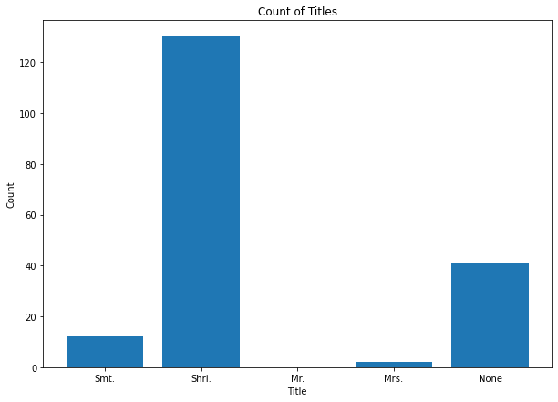

```python
# Plot number of titles'
plt.figure(figsize = (10, 7))
plt.bar(titles_df["Titles"], titles_df["Counts"])
plt.title("Count of Titles")
plt.xlabel("Title")
plt.ylabel('Count')
plt.show()
```

### Mobile No.

The mobile phone number of the Panchayat Officer.

```python
column = goa_proforma_C["Mobile No."]
column
```

```
0      9970451419
1      9764364603
2      9822282013
3      9764007587
4      9764512999
          ...
180    9420107912
181    9421255686
182    9423503452
183    8554904684
184    9921170574
Name: Mobile No., Length: 185, dtype: object
```

```python
print("No. of unique values:", len(column.unique()))
counter = dict(Counter(column))
duplicates = {key:value for key, value in counter.items() if value > 1}
print("Duplicates:", duplicates)
if len(duplicates) > 0:
    print("No. of duplicates:", len(duplicates))

print("No. of null values:", sum(column.isnull()))
```

```
No. of unique values: 171
Duplicates: {9421194391: 2, 9890419521: 2, 9422063482: 2, 9049594355: 2, 9822154237: 2, 7066672547: 2, 9823259969: 2, '---': 3, 9422579459: 2, 9423503452: 2, 9673745449: 2, 9822232014: 2, 9764683821: 2}
No. of duplicates: 13
No. of null values: 0
```

```python
goa_proforma_C[goa_proforma_C["Mobile No."] == 9421194391]
```

|  | Sr.No | Name of the District along with State | Name of Panchayat Officer (V.P. Secretary) | Mobile No. | Email Address |
| --- | --- | --- | --- | --- | --- |
| 10 | 11 | North Goa, Goa | Shri. Francis Fernandes | 9421194391 | NaN |
| 58 | 59 | North Goa, Goa | Shri. Francis Fernandes | 9421194391 | NaN |

```python
goa_proforma_C[goa_proforma_C["Mobile No."] == 9890419521]
```

|  | Sr.No | Name of the District along with State | Name of Panchayat Officer (V.P. Secretary) | Mobile No. | Email Address |
| --- | --- | --- | --- | --- | --- |
| 11 | 12 | North Goa, Goa | Shri. Clifton Azavedo | 9890419521 | NaN |
| 30 | 31 | North Goa, Goa | Shri. Clifton Azavedo | 9890419521 | NaN |

Duplicates in `Mobile No.` are duplicates in rows.

### Email Address

The email address of the Panchayat Officer.

```python
column = goa_proforma_C["Email Address"]
column
```

```
0      NaN
1      NaN
2      NaN
3      NaN
4      NaN
      ...
180    NaN
181    NaN
182    NaN
183    NaN
184    NaN
Name: Email Address, Length: 185, dtype: object
```

```python
print("No. of unique values:", len(column.unique()))
counter = dict(Counter(column))
duplicates = {key:value for key, value in counter.items() if value > 1}
print("Duplicates:", duplicates)
if len(duplicates) > 0:
    print("No. of duplicates:", len(duplicates))

print("No. of null values:", sum(column.isnull()))
```

```
No. of unique values: 4
Duplicates: {nan: 182}
No. of duplicates: 1
No. of null values: 182
```

```python
column.dropna()
```

```
104          mailoswynmas@gmail.com
119    lencydiasjuliao007@gmail.com
121          joslynesteves@gmail.com
Name: Email Address, dtype: object
```

### Sheet E

Sheet E contains information about Disctrict Panchayat Presidents in Goa.

### Sr.No.

Counts the number of Disctrict Panchayat Presidents.

```python
column = goa_proforma_E["Sr.No"]
column
```

```
0    1
1    2
2    3
3    4
Name: Sr.No, dtype: object
```

```python
print("No. of unique values:", len(column.unique()))
```

```
No. of unique values: 4
```

### Name of District along with State

Name of district in Goa.

```python
column = goa_proforma_E["Name of District along with State"]
column
```

```
0    North Goa, GOA
1    North Goa, GOA
2    South Goa, GOA
3    South Goa, GOA
Name: Name of District along with State, dtype: object
```

```python
districts = column.apply(lambda x: str(x[:9]))

print("Unique values:", districts.unique())
print("No. of unique values:", len(districts.unique()))

# Table of number of Sarpanchs in each district
table = districts.value_counts().rename_axis('District').reset_index(name='Count')
table
```

```
Unique values: ['North Goa' 'South Goa']
No. of unique values: 2
```

|  | District | Count |
| --- | --- | --- |
| 0 | South Goa | 2 |
| 1 | North Goa | 2 |

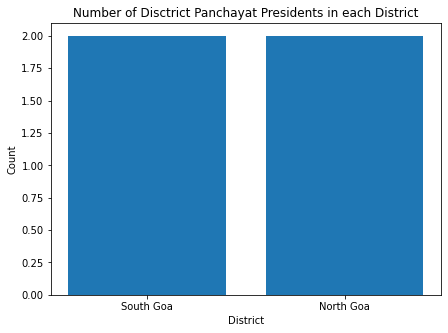

```python
plt.figure(figsize = (7, 5))
plt.bar(table["District"], table["Count"])
plt.title("Number of Disctrict Panchayat Presidents in each District")
plt.xlabel("District")
plt.ylabel("Count")
plt.show()
```

### Name of District Panchayat President

Name of the Disctrict Panchayat President.

```python
column = goa_proforma_E["Name of District Panchayat President"]
column
```

```
0           Smt.Ankita L Navelkar - Adhyaksha
1    Shri. Vasudev L Korgaonkar - Upadhyaksha
2          Shri. Navnaath G. Naik - Adhyaksha
3      Smt. Chitra Parab Fadte  - Upadhyaksha
Name: Name of District Panchayat President, dtype: object
```

```python
print("No. of unique values:", len(column.unique()))
```

```
No. of unique values: 4
```

```python
#Titles of officers
titles = column.apply(lambda x: str(x[:3]))
smt = 0; shr = 0
for title in titles:
    if (title == 'Smt'):
        smt += 1
    elif (title == 'Shr'):
        shr += 1
titles_df = pd.DataFrame(data = {'Titles' : ['Smt.', 'Shri.'],
                                 'Counts' : [smt, shr]})
titles_df
```

|  | Titles | Counts |
| --- | --- | --- |
| 0 | Smt. | 2 |
| 1 | Shri. | 2 |

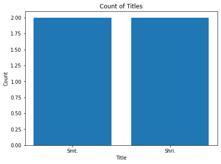

```python
# Plot number of titles'
plt.figure(figsize = (7, 5))
plt.bar(titles_df["Titles"], titles_df["Counts"])
plt.title("Count of Titles")
plt.xlabel("Title")
plt.ylabel('Count')
plt.show()
```

### Address with Pin Code

The address and pin code of the Disctrict Panchayat President.

```python
column = goa_proforma_E["Address with Pin Code"]
column
```

```
0    H.No 247, Lalbag, Vithalpur, P.O. Sanquelim, B...
1           H.No 353, Khalap wado, Canca, Bardez - Goa
2                      H.No 164/1, Bhaati, Sanguem-Goa
3    H.No 73, Near Mal, Kharwada, Bandora, Ponda - Goa
Name: Address with Pin Code, dtype: object
```

```python
print("No. of unique values:", len(column.unique()))
```

```
No. of unique values: 4
```

### Mobile No. / Email Address

The mobile phone number or email address of the Disctrict Panchayat President.

```python
column = goa_proforma_E["Mobile No. / Email Address"]
column
```

```
0    9923446211
1    9850453006
2    9421240037
3    9049666058
Name: Mobile No. / Email Address, dtype: object
```

```python
print("No. of unique values:", len(column.unique()))
```

```
No. of unique values: 4
```

### Sheet F

Sheet F contains information about the Nodal Officer in Goa.  
Since there is only one row in the DataFrame, for each column I will just print out the value in the row.

### Sr.No.

Counts the number of Nodal Officers.

```python
goa_proforma_F["Sr.No"][0]
```

```
1
```

### Name of the State

Name of State in India.

```python
goa_proforma_F["Name of the State"][0]
```

```
'GOA'
```

### Name of the Nodal Officer / Designation

Name of the Nodal Officer and their designation.

```python
goa_proforma_F["Name of the Nodal Officer / Designation"][0]
```

```
'Shri. Gurudas Pilarnekar, Director, Directorate of Panchayats'
```

### Mobile No. / Email Address

The mobile phone number or email address of the Nodal Officer.

```python
goa_proforma_F["Mobile No. / Email Address"][0]
```

```
'9763554136 dir-panc.goa@nic.in'
```

### Postal Details

The address and pin code of the Nodal Officer.

```python
goa_proforma_F["Postal Details"][0]
```

```
'3rd lift, 3rd floor, Junta House, Panaji - Goa'
```